# Individual Math Course Recommendations

Bill Prisbrey

January 07, 2026

**EXPLANATION:**

It provides the statistical distance to the qualifications of successful students in the prior year’s courses (2023). Academic performance roughly decreases with distance and courses with a distance measure larger than three are not recommended.

It also provides individual grade expectations per course based on limited available information about the student and the department’s historical records.

These projected grades have a large margin of error and many students who are projected to perform well end up performing poorly, and vice versa. Individual effort is important. Qualities like motivation and factors like concurrent course load, course schedule, and individual circumstances are not captured in the projections.

# Student ID: 01494417

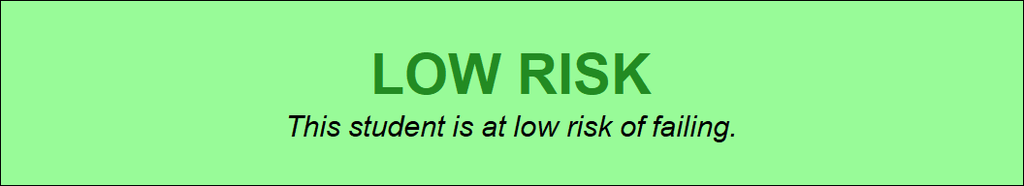

## Distance

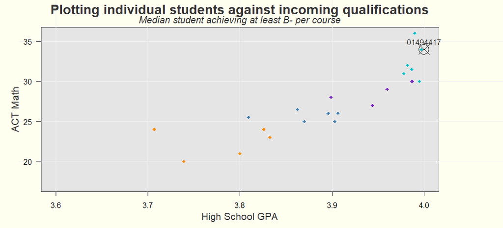

## Projections

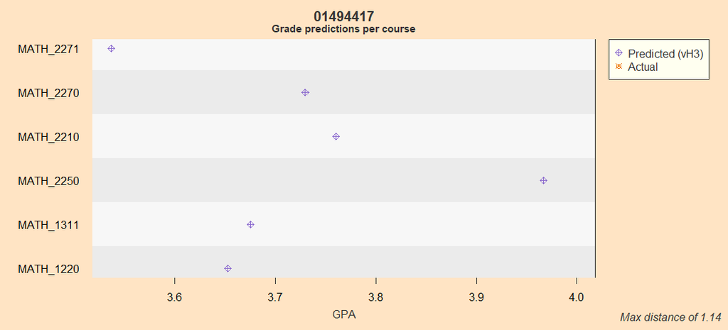

## Table

Student 01494417

| HS GPA | ACT Math |
| --- | --- |
| 4 | 34 |

Distance to median successful student and predicted grades

|  | Distance | Predicted Grade | Median ACT Math | Median HS GPA |
| --- | --- | --- | --- | --- |
| MATH_2271 | 0.51 | 3.54 | 35.0 | 3.95 |
| MATH_2270 | 0.70 | 3.73 | 32.0 | 3.98 |
| MATH_2210 | 0.97 | 3.76 | 31.0 | 3.98 |
| MATH_2250 | 1.00 | 3.97 | 35.0 | 3.80 |
| MATH_1311 | 1.14 | 3.68 | 30.0 | 4.00 |
| MATH_1220 | 1.14 | 3.65 | 30.0 | 3.96 |
| MATH_1320 | 1.19 | 3.74 | 29.0 | 3.92 |
| MATH_1310 | 1.63 | 3.89 | 28.0 | 3.92 |
| MATH_1215 | 1.70 | 3.89 | 27.0 | 3.91 |
| MATH_1210 | 1.81 | 3.77 | 27.0 | 3.92 |
| MATH_1070 | 1.99 | 3.85 | 24.5 | 3.93 |

## Projection explanation

Further explanation of any particular projection is available upon request.

A full explanation of the methodology is available.